# Analýzy k volbám 2018

petr.koci@rozhlas.cz

# 0. Stažní dat ČSÚ

Aktuální k 11. září 2018. [Co všechno data obsahují?](https://volby.cz/opendata/kv2018/KV2018regPopis.pdf).

```r
library(readxl)

# 2018
download.file("https://volby.cz/opendata/kv2018/KV2018reg20181031_xlsx.zip", "KV2018reg20181031_xlsx.zip")
unzip("KV2018reg20181031_xlsx.zip")
zastupitelstva18 <- read_excel("kvrzcoco.xlsx")
strany18 <- read_excel("kvros.xlsx")
kandidati18 <- read_excel("kvrk.xlsx")
file.remove(list.files(pattern="*.xlsx|*.xml|*.zip"))

# 2014
download.file("https://volby.cz/opendata/kv2014/KV2014reg20141014_xlsx.zip", "KV2014reg20141014_xlsx.zip")
unzip("KV2014reg20141014_xlsx.zip")
zastupitelstva14 <- read_excel("kvrzcoco.xlsx")
strany14 <- read_excel("kvros.xlsx")
kandidati14 <- read_excel("kvrk.xlsx")
file.remove(list.files(pattern="*.xlsx|*.xml|*.zip"))

# číselník okresů 2018
download.file("https://volby.cz/opendata/kv2018/KV2018ciselniky20181031.zip", "ciselniky.zip")
unzip("ciselniky.zip")
nuts18 <- read_excel("cnumnuts.xlsx")
file.remove(list.files(pattern="*.xlsx|*.xml|*.zip"))

# číselník politické příslušnosti kandidátů 2018
download.file("https://volby.cz/opendata/kv2018/KV2018ciselniky20181031.zip", "ciselniky.zip")
unzip("ciselniky.zip")
cpp18 <- read_excel("cpp.xlsx")
file.remove(list.files(pattern="*.xlsx|*.xml|*.zip"))

# číselník navrhujících stran 2018
download.file("https://volby.cz/opendata/kv2018/KV2018ciselniky20181031.zip", "ciselniky.zip")
unzip("ciselniky.zip")
cns18 <- read_excel("cns.xlsx")
file.remove(list.files(pattern="*.xlsx|*.xml|*.zip"))
```

# 1. Počet kandidátů na mandát

Jaká je v jednotlivých obcích poptávka po práci v zastupitelstvu?

## Příprava dat

```r
library(tidyverse)
# počet kandidátů v každém zastupitelstvu
kandidati_obce <- kandidati18 %>%
  group_by(KODZASTUP) %>%
  summarise(POCET_KANDIDATU=n())
# počet mandátů v každém zastupitelstvu, odebrat jednotlivé obvody, nechat jen celá zastupitelstva
zastupitelstva_mandaty <- zastupitelstva18 %>%
  filter(OBVODY!=2) %>%
  left_join(nuts18, by=c("OKRES" = "NUMNUTS")) %>%
  select(KODZASTUP, MANDATY, NAZEVZAST, NAZEVNUTS)
```

## Obce, kde nekandiduje nikdo

Našli jsme devět obcí, kde nekandiduje nikdo. Největší z nich je Lipovec v okrese Blansko, nejbližší Roblín v Praze-západ.

```r
zastupitelstva_mandaty %>%
  anti_join(kandidati_obce) %>%
  select(NAZEVZAST, NAZEVNUTS, MANDATY) %>%
  arrange(desc(MANDATY))
```

| NAZEVZAST | NAZEVNUTS | MANDATY |
| --- | --- | --- |
| Lipovec | Blansko | 15 |
| Hodějice | Vyškov | 9 |
| Litichovice | Benešov | 7 |
| Němčovice | Rokycany | 7 |
| Kluky | Mladá Boleslav | 7 |
| Roblín | Praha-západ | 7 |
| Dlouhá Lhota | Blansko | 7 |
| Ždírec | Havlíčkův Brod | 5 |
| Němčice | Strakonice | 5 |

Týká se to obcí, které mají celkem 3050 obyvatel.

```r
zastupitelstva_mandaty %>%
  anti_join(kandidati_obce) %>%
  arrange(desc(MANDATY)) %>%
  left_join(zastupitelstva18) %>%
  select(POCOBYV) %>%
  sum()
```

```
[1] 3050
```

## Kde je kandidátů míň než mandátů

V sedmnácti obcích je kandidátů méně než mandátů a nepodaří se v nich tedy naplnit zastupitelstvo. Největší takovou obcí jsou Tatobity v okrese Semily.

```r
zastupitelstva_mandaty %>%
  left_join(kandidati_obce) %>%
  mutate(KANDIDATU_NA_MANDAT=POCET_KANDIDATU/MANDATY) %>%
  filter(KANDIDATU_NA_MANDAT<1) %>%
  select(NAZEVZAST,NAZEVNUTS,MANDATY,POCET_KANDIDATU,KANDIDATU_NA_MANDAT) %>%
  arrange(KANDIDATU_NA_MANDAT)
```

| NAZEVZAST | NAZEVNUTS | MANDATY | POCET_KANDIDATU | KANDIDATU_NA_MANDAT |
| --- | --- | --- | --- | --- |
| Kbelnice | Jičín | 7 | 1 | 0.1428571 |
| Horšice | Plzeň-jih | 7 | 1 | 0.1428571 |
| Střítež | Žďár nad Sázavou | 5 | 1 | 0.2000000 |
| Kadlín | Mělník | 7 | 2 | 0.2857143 |
| Víska u Jevíčka | Svitavy | 7 | 2 | 0.2857143 |
| Tatobity | Semily | 15 | 6 | 0.4000000 |
| Skomelno | Rokycany | 7 | 3 | 0.4285714 |
| Bolkov | Plzeň-jih | 9 | 7 | 0.7777778 |
| Záboří | Strakonice | 9 | 7 | 0.7777778 |
| Děkov | Rakovník | 5 | 4 | 0.8000000 |

[output cut: 7 more lines]

Týká se to obcí, které mají celkem 5400 obyvatel.

```r
zastupitelstva_mandaty %>%
  left_join(kandidati_obce) %>%
  mutate(KANDIDATU_NA_MANDAT=POCET_KANDIDATU/MANDATY) %>%
  filter(KANDIDATU_NA_MANDAT<1) %>%
  arrange(KANDIDATU_NA_MANDAT) %>%
  left_join(zastupitelstva18) %>%
  select(POCOBYV) %>%
  sum()
```

```
[1] 5400
```

## Kde je přesně jeden kandidát na mandát

V 857 obcích, tedy zhruba ve 13 procentech ze všech, jsou volby jen formalitou, protože kandidátů je stejně jako mandátů.

```r
zastupitelstva_mandaty %>%
  left_join(kandidati_obce) %>%
  mutate(KANDIDATU_NA_MANDAT=POCET_KANDIDATU/MANDATY) %>%
  filter(KANDIDATU_NA_MANDAT==1) %>%
  select(NAZEVZAST,NAZEVNUTS,MANDATY,POCET_KANDIDATU,KANDIDATU_NA_MANDAT) %>%
  arrange(desc(MANDATY))
```

| NAZEVZAST | NAZEVNUTS | MANDATY | POCET_KANDIDATU | KANDIDATU_NA_MANDAT |
| --- | --- | --- | --- | --- |
| Dolní Břežany | Praha-západ | 17 | 17 | 1 |
| Jakartovice | Opava | 15 | 15 | 1 |
| Otice | Opava | 15 | 15 | 1 |
| Pavlovice u Přerova | Přerov | 15 | 15 | 1 |
| Soběchleby | Přerov | 15 | 15 | 1 |
| Louňovice pod Blaníkem | Benešov | 15 | 15 | 1 |
| Netvořice | Benešov | 15 | 15 | 1 |
| Vrchotovy Janovice | Benešov | 15 | 15 | 1 |
| Praskolesy | Beroun | 15 | 15 | 1 |
| Tlustice | Beroun | 15 | 15 | 1 |

[output cut: 847 more lines]

Týká se to obcí, které mají celkem 363 248 obyvatel a 7105 kandidátů, kteří mají své mandáty už jisté.

```r
zastupitelstva_mandaty %>%
  left_join(kandidati_obce) %>%
  mutate(KANDIDATU_NA_MANDAT=POCET_KANDIDATU/MANDATY) %>%
  filter(KANDIDATU_NA_MANDAT==1) %>%
  arrange(desc(MANDATY)) %>%
  left_join(zastupitelstva18) %>%
  select(POCOBYV) %>%
  sum()
```

```
[1] 363248
```

## Kde je největší poptávka po práci v zastupitelstvu?

Nejvíc lidí usiluje o jeden mandát v Praze (24 kandidátů na mandát) a v krajských městech. Mimo krajská města a jejich městské části je mimořádně vysoká konkurence v Šumperku, ve Strakonicích,v Hodoníně, v Jirkově, v České Lípě či v Opavě (13 kandidátů na mandát).

```r
zastupitelstva_mandaty %>%
  left_join(kandidati_obce) %>%
  mutate(KANDIDATU_NA_MANDAT=POCET_KANDIDATU/MANDATY) %>%
  distinct() %>%
  select(NAZEVZAST, NAZEVNUTS, MANDATY, POCET_KANDIDATU, KANDIDATU_NA_MANDAT) %>%
  arrange(desc(KANDIDATU_NA_MANDAT))
```

| NAZEVZAST | NAZEVNUTS | MANDATY | POCET_KANDIDATU | KANDIDATU_NA_MANDAT |
| --- | --- | --- | --- | --- |
| Praha hl.m. | Hlavní město Praha | 65 | 1582 | 24.338462 |
| Brno | Brno-město | 55 | 991 | 18.018182 |
| Plzeň | Plzeň-město | 47 | 722 | 15.361702 |
| Olomouc | Olomouc | 45 | 689 | 15.311111 |
| Ústí nad Labem | Ústí nad Labem | 37 | 555 | 15.000000 |
| Karlovy Vary | Karlovy Vary | 35 | 525 | 15.000000 |
| Šumperk | Šumperk | 27 | 380 | 14.074074 |
| Praha 5 | Hlavní město Praha | 43 | 602 | 14.000000 |
| Strakonice | Strakonice | 21 | 294 | 14.000000 |
| Hodonín | Hodonín | 31 | 434 | 14.000000 |

[output cut: 990 more lines]

# 2. “Skryté” kandidátky

Systematicky „přebarvené” kandidátky jsme nenašli. Pokud o nějaké víte, dejte vědět, mohlo nám něco utéct.

Je to okrajový jev, který se týká méně než jednoho ze sta kandidátů. Přesto se dají najít případy, kdy se na místní úrovni na jedné kandidátce sejdou z hlediska celostátní politiky překvapivé kombinace, například Zelený na kandidátce ODS, člen ODS či ČSSD u lidovců, komunista u sociálních demokratů, Svobodný u SPD nebo Okamurovec na kandidátce komunistů, člen ANO 2011 u STAN nebo u SPD.

Většina kandidátů (180 894, tedy 83,5 procenta) má jinou politickou příslušnost než navrhující stranu.

```r
kandidati18 %>%
  filter(PSTRANA!=NSTRANA) %>%
  nrow()
```

```
[1] 180894
```

```r
kandidati18 %>%
  filter(PSTRANA!=NSTRANA) %>%
  group_by(PSTRANA) %>%
  summarise(KANDIDATI=n()) %>%
  left_join(cpp18) %>%
  arrange(desc(KANDIDATI))
```

| PSTRANA | KANDIDATI | NAZEV_STRP | ZKRATKAP30 | ZKRATKAP8 |
| --- | --- | --- | --- | --- |
| 99 | 179265 | Bez politické příslušnosti | Bez politické příslušnosti | BEZPP |
| 1 | 216 | Křesťan.a demokrat.unie-Českosl.strana lidová | Křesť.demokr.unie-Čs.str.lid. | KDU-ČSL |
| 53 | 202 | Občanská demokratická strana | Občanská demokratická strana | ODS |
| 7 | 190 | Česká strana sociálně demokratická | Česká str.sociálně demokrat. | ČSSD |
| 47 | 184 | Komunistická strana Čech a Moravy | Komunistická str.Čech a Moravy | KSČM |
| 721 | 157 | TOP 09 | TOP 09 | TOP 09 |
| 5 | 82 | Strana zelených | Strana zelených | Zelení |
| 714 | 76 | Strana svobodných občanů | Strana svobodných občanů | Svobodní |
| 768 | 72 | ANO 2011 | ANO 2011 | ANO |
| 720 | 43 | Česká pirátská strana | Česká pirátská strana | Piráti |

[output cut: 64 more lines]

Nejčastěji členové jiných stran kandidují jako nezávislí kandidáti (1158), dále pak za ODS (75), za STAN (52), za lidovce (40), za KSČM (35), za NEZÁVISLÉ (31), Piráty (24), Svobodné (19), SPD (19), a TOP 09 (18).

```r
kandidati18 %>%
  filter(PSTRANA!=NSTRANA) %>%
  filter(PSTRANA!=99) %>%
  group_by(NSTRANA) %>%
  summarise(KANDIDATI=n()) %>%
  left_join(cns18) %>%
  arrange(desc(KANDIDATI))
```

| NSTRANA | KANDIDATI | NAZEV_STRN | ZKRATKAN30 | ZKRATKAN8 |
| --- | --- | --- | --- | --- |
| 80 | 1158 | Nezávislý kandidát | Nezávislý kandidát | NK |
| 53 | 75 | Občanská demokratická strana | Občanská demokratická strana | ODS |
| 166 | 52 | STAROSTOVÉ A NEZÁVISLÍ | STAROSTOVÉ A NEZÁVISLÍ | STAN |
| 1 | 40 | Křesťan.a demokrat.unie-Českosl.strana lidová | Křesť.demokr.unie-Čs.str.lid. | KDU-ČSL |
| 47 | 35 | Komunistická strana Čech a Moravy | Komunistická str.Čech a Moravy | KSČM |
| 88 | 31 | NEZÁVISLÍ | NEZÁVISLÍ | NEZ |
| 720 | 24 | Česká pirátská strana | Česká pirátská strana | Piráti |
| 714 | 19 | Strana svobodných občanů | Strana svobodných občanů | Svobodní |
| 1114 | 19 | Svoboda a přímá demokracie - Tomio Okamura (SPD) | Svob.a př.dem.-T.Okamura (SPD) | SPD |
| 721 | 18 | TOP 09 | TOP 09 | TOP 09 |

[output cut: 48 more lines]

## Členové stran, kteří kandidují jako nezávislí kandidáti

```r
kandidati18 %>%
  filter(PSTRANA!=NSTRANA) %>%
  filter(PSTRANA!=99) %>%
  filter(NSTRANA==80) %>%
  left_join(cpp18) %>%
  group_by(ZKRATKAP30) %>%
  summarise(POCET=n()) %>%
  arrange(desc(POCET))
```

| ZKRATKAP30 | POCET |
| --- | --- |
| Občanská demokratická strana | 181 |
| Komunistická str.Čech a Moravy | 178 |
| Křesť.demokr.unie-Čs.str.lid. | 176 |
| Česká str.sociálně demokrat. | 165 |
| TOP 09 | 105 |
| ANO 2011 | 68 |
| Strana zelených | 38 |
| Česká pirátská strana | 34 |
| Strana svobodných občanů | 24 |
| Svob.a př.dem.-T.Okamura (SPD) | 23 |

[output cut: 42 more lines]

```r
kandidati18 %>%
  filter(PSTRANA!=NSTRANA) %>%
  filter(PSTRANA!=99) %>%
  filter(NSTRANA==80) %>%
  left_join(cpp18)
```

| OKRES | KODZASTUP | COBVODU | POR_STR_HL | OSTRANA | PORCISLO | JMENO | PRIJMENI | TITULPRED | TITULZA | VEK | POVOLANI | BYDLISTEN | PSTRANA | NSTRANA | PLATNOST | POCHLASU | POCHL_PRES | POCPROCVSE | MANDAT | PORADIMAND | PORADINAHR | POHLAVI | DATNAR | NAZEV_STRP | ZKRATKAP30 | ZKRATKAP8 |
| --- | --- | --- | --- | --- | --- | --- | --- | --- | --- | --- | --- | --- | --- | --- | --- | --- | --- | --- | --- | --- | --- | --- | --- | --- | --- | --- |
| 8104 | 500046 | 1 | 2 | 902 | 6 | Jiří | Absolon | Bc. | NA | 59 | ředitel domova seniorů | Libhošť | 7 | 80 | A | 0 | 0 | 0 | N | 0 | 0 | NA | NA | Česká strana sociálně demokratická | Česká str.sociálně demokrat. | ČSSD |
| 7203 | 500071 | 1 | 2 | 902 | 1 | Alena | Malúšková | Mgr. | Ph.D. | 32 | učitelka 1. stupně na základní škole | Poličná | 7 | 80 | A | 0 | 0 | 0 | N | 0 | 0 | NA | NA | Česká strana sociálně demokratická | Česká str.sociálně demokrat. | ČSSD |
| 7203 | 500071 | 1 | 3 | 903 | 1 | Vladimír | Místecký | NA | NA | 66 | starosta obce Poličná | Poličná | 47 | 80 | A | 0 | 0 | 0 | N | 0 | 0 | NA | NA | Komunistická strana Čech a Moravy | Komunistická str.Čech a Moravy | KSČM |
| 7203 | 500071 | 1 | 3 | 903 | 11 | Libuše | Dopiráková | NA | NA | 63 | OSVČ | Poličná | 47 | 80 | A | 0 | 0 | 0 | N | 0 | 0 | NA | NA | Komunistická strana Čech a Moravy | Komunistická str.Čech a Moravy | KSČM |
| 7203 | 500071 | 1 | 3 | 903 | 14 | Rostislav | Šťastný | NA | NA | 69 | důchodce | Poličná | 47 | 80 | A | 0 | 0 | 0 | N | 0 | 0 | NA | NA | Komunistická strana Čech a Moravy | Komunistická str.Čech a Moravy | KSČM |
| 1100 | 500143 | 1 | 8 | 477 | 11 | Miloš | Petr | Ing. | NA | 31 | vedoucí třídící linky | Praha 5 | 1176 | 80 | A | 0 | 0 | 0 | N | 0 | 0 | NA | NA | REALISTÉ | REALISTÉ | REAL |
| 1100 | 500143 | 1 | 8 | 477 | 12 | Jan | Pavlišta | Ing. | NA | 36 | aplikační specialista | Praha 5 | 1176 | 80 | A | 0 | 0 | 0 | N | 0 | 0 | NA | NA | REALISTÉ | REALISTÉ | REAL |
| 1100 | 500143 | 1 | 8 | 477 | 41 | Radek | Pokorný | Mgr. | NA | 50 | lékárník | Praha 5 | 1176 | 80 | A | 0 | 0 | 0 | N | 0 | 0 | NA | NA | REALISTÉ | REALISTÉ | REAL |
| 1100 | 500178 | 1 | 2 | 1435 | 12 | Barbora | Peterková | Ing. arch. | NA | 65 | architektka | Praha 6 - Dejvice | 129 | 80 | A | 0 | 0 | 0 | N | 0 | 0 | NA | NA | SNK Evropští demokraté | SNK Evropští demokraté | SNK ED |
| 1100 | 500186 | 1 | 6 | 901 | 4 | Kamil Vavřinec | Mareš | Ing. | NA | 31 | jaderný chemik, místostarosta Prahy 7 | Praha 7 | 1 | 80 | A | 0 | 0 | 0 | N | 0 | 0 | NA | NA | Křesťan.a demokrat.unie-Českosl.strana lidová | Křesť.demokr.unie-Čs.str.lid. | KDU-ČSL |

[output cut: 990 more lines]

## Členové jiných stran, kteří kandidují za ODS

```r
kandidati18 %>%
  filter(PSTRANA!=NSTRANA) %>%
  filter(PSTRANA!=99) %>%
  filter(NSTRANA==53) %>%
  left_join(cpp18) %>%
  group_by(ZKRATKAP30) %>%
  summarise(POCET=n()) %>%
  arrange(desc(POCET))
```

| ZKRATKAP30 | POCET |
| --- | --- |
| Strana soukromníků ČR | 24 |
| TOP 09 | 22 |
| Strana svobodných občanů | 20 |
| REALISTÉ | 3 |
| Křesť.demokr.unie-Čs.str.lid. | 2 |
| Česká pirátská strana | 1 |
| Konzervativní strana | 1 |
| Koruna Česká (monarch.strana) | 1 |
| Strana zelených | 1 |

```r
kandidati18 %>%
  filter(PSTRANA!=NSTRANA) %>%
  filter(PSTRANA!=99) %>%
  filter(NSTRANA==53) %>%
  left_join(cpp18)
```

| OKRES | KODZASTUP | COBVODU | POR_STR_HL | OSTRANA | PORCISLO | JMENO | PRIJMENI | TITULPRED | TITULZA | VEK | POVOLANI | BYDLISTEN | PSTRANA | NSTRANA | PLATNOST | POCHLASU | POCHL_PRES | POCPROCVSE | MANDAT | PORADIMAND | PORADINAHR | POHLAVI | DATNAR | NAZEV_STRP | ZKRATKAP30 | ZKRATKAP8 |
| --- | --- | --- | --- | --- | --- | --- | --- | --- | --- | --- | --- | --- | --- | --- | --- | --- | --- | --- | --- | --- | --- | --- | --- | --- | --- | --- |
| 1100 | 500089 | 1 | 3 | 53 | 23 | Livia | Kubátová | NA | NA | 63 | důchodce | Praha 2 | 716 | 53 | A | 0 | 0 | 0 | N | 0 | 0 | NA | NA | Strana soukromníků České republiky | Strana soukromníků ČR | Soukromníci |
| 1100 | 500097 | 1 | 6 | 1310 | 29 | Jitka | Linková | NA | NA | 52 | živnostník | Praha 3 | 716 | 53 | A | 0 | 0 | 0 | N | 0 | 0 | NA | NA | Strana soukromníků České republiky | Strana soukromníků ČR | Soukromníci |
| 1100 | 500178 | 1 | 10 | 53 | 7 | Jan | Dočekal | NA | NA | 54 | manažer u Deutsche Automobil Treuhand | MČ Praha 6 | 714 | 53 | A | 0 | 0 | 0 | N | 0 | 0 | NA | NA | Strana svobodných občanů | Strana svobodných občanů | Svobodní |
| 1100 | 500178 | 1 | 10 | 53 | 13 | Jaromír | Kaláb | Ing. | NA | 37 | ekonom | MČ Praha 6 | 714 | 53 | A | 0 | 0 | 0 | N | 0 | 0 | NA | NA | Strana svobodných občanů | Strana svobodných občanů | Svobodní |
| 1100 | 500178 | 1 | 10 | 53 | 16 | Bedřich | Danda | NA | NA | 79 | podnikatel | MČ Praha 6 | 716 | 53 | A | 0 | 0 | 0 | N | 0 | 0 | NA | NA | Strana soukromníků České republiky | Strana soukromníků ČR | Soukromníci |
| 1100 | 500178 | 1 | 10 | 53 | 20 | Jana | Frková | doc. Ing. | Ph.D. | 62 | pedagog | MČ Praha 6 | 714 | 53 | A | 0 | 0 | 0 | N | 0 | 0 | NA | NA | Strana svobodných občanů | Strana svobodných občanů | Svobodní |
| 1100 | 500178 | 1 | 10 | 53 | 26 | Ondřej | Stárek | NA | NA | 40 | programátor | MČ Praha 6 | 714 | 53 | A | 0 | 0 | 0 | N | 0 | 0 | NA | NA | Strana svobodných občanů | Strana svobodných občanů | Svobodní |
| 1100 | 500178 | 1 | 10 | 53 | 38 | Václav | Brož | NA | NA | 18 | programátor, student | MČ Praha 6 | 714 | 53 | A | 0 | 0 | 0 | N | 0 | 0 | NA | NA | Strana svobodných občanů | Strana svobodných občanů | Svobodní |
| 1100 | 500224 | 1 | -4 | 53 | 10 | Lukáš | Cvrček | PhDr. | Ph.D. | 41 | historik a genealog | Praha 10 | 714 | 53 | A | 0 | 0 | 0 | N | 0 | 0 | NA | NA | Strana svobodných občanů | Strana svobodných občanů | Svobodní |
| 1100 | 500224 | 1 | -4 | 53 | 15 | Filip | Cvrček | NA | NA | 23 | překladatel | Praha 10 | 714 | 53 | A | 0 | 0 | 0 | N | 0 | 0 | NA | NA | Strana svobodných občanů | Strana svobodných občanů | Svobodní |

[output cut: 65 more lines]

## Členové jiných stran, kteří kandidují za STAN

```r
kandidati18 %>%
  filter(PSTRANA!=NSTRANA) %>%
  filter(PSTRANA!=99) %>%
  filter(NSTRANA==166) %>%
  left_join(cpp18) %>%
  group_by(ZKRATKAP30) %>%
  summarise(POCET=n()) %>%
  arrange(desc(POCET))
```

| ZKRATKAP30 | POCET |
| --- | --- |
| TOP 09 | 10 |
| Česká pirátská strana | 6 |
| Křesť.demokr.unie-Čs.str.lid. | 6 |
| Česká str.sociálně demokrat. | 4 |
| Občanská demokratická strana | 4 |
| ZVUK 12 | 4 |
| Hnutí SOL | 3 |
| Liberálně ekologická strana | 3 |
| Pro Třebíč | 3 |
| "Hnutí Praha-Kunratice" | 1 |

[output cut: 8 more lines]

```r
kandidati18 %>%
  filter(PSTRANA!=NSTRANA) %>%
  filter(PSTRANA!=99) %>%
  filter(NSTRANA==166) %>%
  left_join(cpp18)
```

| OKRES | KODZASTUP | COBVODU | POR_STR_HL | OSTRANA | PORCISLO | JMENO | PRIJMENI | TITULPRED | TITULZA | VEK | POVOLANI | BYDLISTEN | PSTRANA | NSTRANA | PLATNOST | POCHLASU | POCHL_PRES | POCPROCVSE | MANDAT | PORADIMAND | PORADINAHR | POHLAVI | DATNAR | NAZEV_STRP | ZKRATKAP30 | ZKRATKAP8 |
| --- | --- | --- | --- | --- | --- | --- | --- | --- | --- | --- | --- | --- | --- | --- | --- | --- | --- | --- | --- | --- | --- | --- | --- | --- | --- | --- |
| 1100 | 500054 | 1 | -8 | 1104 | 10 | Martin | Kotas | NA | NA | 44 | kavárník, organizátor pražských kulturních akcí | Praha 1 | 795 | 166 | A | 0 | 0 | 0 | N | 0 | 0 | NA | NA | Liberálně ekologická strana | Liberálně ekologická strana | LES |
| 1100 | 500054 | 1 | -8 | 1104 | 19 | Robert | Jíša | NA | NA | 48 | hudební skladatel | Praha 1 | 795 | 166 | A | 0 | 0 | 0 | N | 0 | 0 | NA | NA | Liberálně ekologická strana | Liberálně ekologická strana | LES |
| 1100 | 500054 | 1 | -8 | 1104 | 24 | Kateřina | Bursíková Jacques | PhDr. | NA | 47 | ředitelka coworkingového centra Sněmovní 7 | Praha 1 | 795 | 166 | A | 0 | 0 | 0 | N | 0 | 0 | NA | NA | Liberálně ekologická strana | Liberálně ekologická strana | LES |
| 2103 | 532053 | 1 | 6 | 1315 | 4 | Jakub | VÁCLAVOVIČ | NA | NA | 23 | pedagog | Kladno | 720 | 166 | A | 0 | 0 | 0 | N | 0 | 0 | NA | NA | Česká pirátská strana | Česká pirátská strana | Piráti |
| 2104 | 533289 | 1 | 1 | 166 | 2 | Martin | Vízek | NA | NA | 36 | obchodní poradce | Dobřichov | 7 | 166 | A | 0 | 0 | 0 | N | 0 | 0 | NA | NA | Česká strana sociálně demokratická | Česká str.sociálně demokrat. | ČSSD |
| 2104 | 533289 | 1 | 1 | 166 | 3 | Pavlína | Bohatá | NA | NA | 51 | administrativní pracovnice | Dobřichov | 7 | 166 | A | 0 | 0 | 0 | N | 0 | 0 | NA | NA | Česká strana sociálně demokratická | Česká str.sociálně demokrat. | ČSSD |
| 2104 | 533581 | 1 | 3 | 166 | 4 | Ivana | Nečasová | NA | NA | 53 | úřednice | Plaňany | 769 | 166 | A | 0 | 0 | 0 | N | 0 | 0 | NA | NA | Řád národa - Vlastenecká unie | Řád národa - Vlastenecká unie | ŘN - VU |
| 2109 | 538094 | 1 | 5 | 1350 | 7 | Markéta | Bahníková | Ing. arch. | NA | 50 | architektka | Stará Boleslav | 1 | 166 | A | 0 | 0 | 0 | N | 0 | 0 | NA | NA | Křesťan.a demokrat.unie-Českosl.strana lidová | Křesť.demokr.unie-Čs.str.lid. | KDU-ČSL |
| 2109 | 538094 | 1 | 5 | 1350 | 11 | Filip | Vaněk | Mgr. | NA | 37 | advokát | Stará Boleslav | 721 | 166 | A | 0 | 0 | 0 | N | 0 | 0 | NA | NA | TOP 09 | TOP 09 | TOP 09 |
| 2109 | 538094 | 1 | 5 | 1350 | 18 | Veronika | Hezinová | Bc. | NA | 36 | technik kvality | Stará Boleslav | 1 | 166 | A | 0 | 0 | 0 | N | 0 | 0 | NA | NA | Křesťan.a demokrat.unie-Českosl.strana lidová | Křesť.demokr.unie-Čs.str.lid. | KDU-ČSL |

[output cut: 42 more lines]

## Členové jiných stran, kteří kandidují za KSČM

```r
kandidati18 %>%
  filter(PSTRANA!=NSTRANA) %>%
  filter(PSTRANA!=99) %>%
  filter(NSTRANA==47) %>%
  left_join(cpp18) %>%
  group_by(ZKRATKAP30) %>%
  summarise(POCET=n()) %>%
  arrange(desc(POCET))
```

| ZKRATKAP30 | POCET |
| --- | --- |
| Strana demokrat.socialismu | 13 |
| Komunistická str.Českosloven. | 7 |
| Strana Práv Občanů ZEMANOVCI | 7 |
| Česká str.sociálně demokrat. | 4 |
| Řád národa - Vlastenecká unie | 2 |
| NE-VOLIM.CZ | 1 |
| Svob.a př.dem.-T.Okamura (SPD) | 1 |

```r
kandidati18 %>%
  filter(PSTRANA!=NSTRANA) %>%
  filter(PSTRANA!=99) %>%
  filter(NSTRANA==47) %>%
  left_join(cpp18)
```

| OKRES | KODZASTUP | COBVODU | POR_STR_HL | OSTRANA | PORCISLO | JMENO | PRIJMENI | TITULPRED | TITULZA | VEK | POVOLANI | BYDLISTEN | PSTRANA | NSTRANA | PLATNOST | POCHLASU | POCHL_PRES | POCPROCVSE | MANDAT | PORADIMAND | PORADINAHR | POHLAVI | DATNAR | NAZEV_STRP | ZKRATKAP30 | ZKRATKAP8 |
| --- | --- | --- | --- | --- | --- | --- | --- | --- | --- | --- | --- | --- | --- | --- | --- | --- | --- | --- | --- | --- | --- | --- | --- | --- | --- | --- |
| 1100 | 500089 | 1 | 9 | 47 | 5 | Milan | Neubert | RNDr. | Ph.D. | 63 | pracovník ve výkumu a vývoji | Praha 2 | 74 | 47 | A | 0 | 0 | 0 | N | 0 | 0 | NA | NA | Strana demokratického socialismu | Strana demokrat.socialismu | SDS |
| 1100 | 500097 | 1 | 2 | 47 | 10 | Karel | Hanauer | NA | NA | 52 | programátor | Praha 3 | 74 | 47 | A | 0 | 0 | 0 | N | 0 | 0 | NA | NA | Strana demokratického socialismu | Strana demokrat.socialismu | SDS |
| 1100 | 500224 | 1 | -3 | 47 | 2 | Lubomír | Ledl | JUDr. | NA | 66 | poradce ústavního činitele | Praha 10 | 74 | 47 | A | 0 | 0 | 0 | N | 0 | 0 | NA | NA | Strana demokratického socialismu | Strana demokrat.socialismu | SDS |
| 1100 | 500224 | 1 | -3 | 47 | 31 | Ivanka | Kopecká | Ing. | NA | 76 | důchodce | Praha 10 | 74 | 47 | A | 0 | 0 | 0 | N | 0 | 0 | NA | NA | Strana demokratického socialismu | Strana demokrat.socialismu | SDS |
| 8105 | 507270 | 1 | 8 | 47 | 2 | Jindřich | Skařupa | Ing. | NA | 63 | OSVČ | Hradec nad Moravicí | 93 | 47 | A | 0 | 0 | 0 | N | 0 | 0 | NA | NA | Komunistická strana Československa | Komunistická str.Českosloven. | KSČ |
| 8105 | 507270 | 1 | 8 | 47 | 6 | Milan | Onderka | NA | NA | 28 | ředitel ekonomického úseku | Hradec nad Moravicí - Jakubčovice | 93 | 47 | A | 0 | 0 | 0 | N | 0 | 0 | NA | NA | Komunistická strana Československa | Komunistická str.Českosloven. | KSČ |
| 8105 | 507270 | 1 | 8 | 47 | 8 | Dana | Gebauerová | NA | NA | 66 | důchodkyně | Hradec nad Moravicí - Bohučovice | 93 | 47 | A | 0 | 0 | 0 | N | 0 | 0 | NA | NA | Komunistická strana Československa | Komunistická str.Českosloven. | KSČ |
| 8105 | 507270 | 1 | 8 | 47 | 17 | Pavel | Kozelský | NA | NA | 73 | OSVČ | Hradec nad Moravicí | 93 | 47 | A | 0 | 0 | 0 | N | 0 | 0 | NA | NA | Komunistická strana Československa | Komunistická str.Českosloven. | KSČ |
| 2102 | 531995 | 1 | 4 | 47 | 2 | Tomáš | Cibulka | NA | NA | 35 | ekonom | Nová Ves | 7 | 47 | A | 0 | 0 | 0 | N | 0 | 0 | NA | NA | Česká strana sociálně demokratická | Česká str.sociálně demokrat. | ČSSD |
| 2104 | 533891 | 1 | 1 | 47 | 2 | Evžen | Koller | NA | NA | 58 | úředník | Vrbčany | 769 | 47 | A | 0 | 0 | 0 | N | 0 | 0 | NA | NA | Řád národa - Vlastenecká unie | Řád národa - Vlastenecká unie | ŘN - VU |

[output cut: 25 more lines]

Další kombinace na vyžádání.

# 3. Obce, kde se od minulých voleb změnil počet mandátů

Obce si mohou v mezích daných zákonem samy stanovit, kolik budou mít zastupitelů.

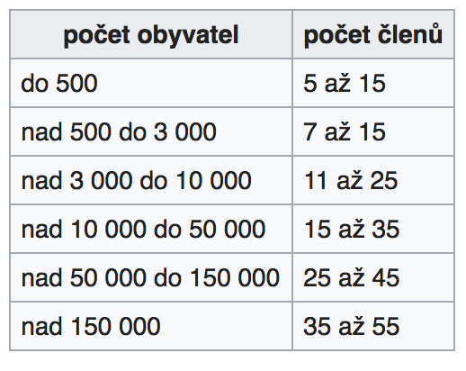

Zajímavé to může být u obcí od 500 do 10 tisíc obyvatel. Ty se totiž mohou samy rozhodnout, budou-li mít méně než 15 zastupitelů. V takovém případě jim odpadá zákonná povinnost volit radu obce. Podrobněji o tom píše například [František Korbel v Moderní obci](https://moderniobec.cz/snizeni-poctu-zastupitelu/).

## Obce, kde se od minulých voleb změnil počet zastupitelů

Ve 356 se obcích se od minulých voleb změnil počet zastupitelů.

```r
zastupitelstva14 %>%
  filter(OBVODY!=2) %>%
  select(TYPZASTUP, DRUHZASTUP, KODZASTUP, NAZEVZAST, MANDATY14=MANDATY) %>%
  left_join(zastupitelstva18) %>%
  filter(MANDATY14!=MANDATY) %>%
  select(NAZEVZAST, OKRES, MANDATY14, MANDATY18=MANDATY) %>%
  arrange(desc(MANDATY18)) %>%
  left_join(nuts18, by=c("OKRES"="NUMNUTS")) %>%
  filter(NAZEVZAST!="Praha 9" & NAZEVZAST!="Lišov") %>%
  select(NAZEVZAST, OKRES=NAZEVNUTS, MANDATY14, MANDATY18)
```

| NAZEVZAST | OKRES | MANDATY14 | MANDATY18 |
| --- | --- | --- | --- |
| Praha 10 | Hlavní město Praha | 40 | 45 |
| Praha 5 | Hlavní město Praha | 45 | 43 |
| Bílina | Teplice | 30 | 29 |
| Benešov | Benešov | 27 | 23 |
| Litovel | Olomouc | 25 | 21 |
| Lovosice | Litoměřice | 25 | 21 |
| Praha 18 | Hlavní město Praha | 21 | 19 |
| Tlučná | Plzeň-sever | 15 | 19 |
| Rožmitál pod Třemšínem | Příbram | 19 | 17 |
| Svinov | Ostrava-město | 19 | 17 |

[output cut: 346 more lines]

Těchto 34 obcí se rozhodlo počet zastupitelů snížit pod 15 a zbavit se tak zákonné povinnosti volit radu obce.

```r
zastupitelstva14 %>%
  filter(OBVODY!=2) %>%
  select(TYPZASTUP, DRUHZASTUP, KODZASTUP, NAZEVZAST, MANDATY14=MANDATY) %>%
  left_join(zastupitelstva18) %>%
  filter(MANDATY14!=MANDATY) %>%
  select(NAZEVZAST, OKRES, MANDATY14, MANDATY18=MANDATY) %>%
  arrange(desc(MANDATY18)) %>%
  left_join(nuts18, by=c("OKRES"="NUMNUTS")) %>%
  filter(NAZEVZAST!="Praha 9" & NAZEVZAST!="Lišov") %>%
  select(NAZEVZAST, OKRES=NAZEVNUTS, MANDATY14, MANDATY18) %>%
  filter(MANDATY18<15&MANDATY14>14) %>%
  slice(1:34)
```

| NAZEVZAST | OKRES | MANDATY14 | MANDATY18 |
| --- | --- | --- | --- |
| Řepov | Mladá Boleslav | 15 | 13 |
| Hostouň | Domažlice | 15 | 13 |
| Stařeč | Třebíč | 15 | 13 |
| Traplice | Uherské Hradiště | 15 | 13 |
| Bukovec | Frýdek-Místek | 15 | 11 |
| Leština | Šumperk | 15 | 11 |
| Olešnice | České Budějovice | 15 | 11 |
| Klenčí pod Čerchovem | Domažlice | 15 | 11 |
| Žihobce | Klatovy | 15 | 11 |
| Příchovice | Plzeň-jih | 15 | 11 |

[output cut: 24 more lines]

Těchto 12 obcí naopak zvýšilo počet zastupitelů a na 15 a povinnost volit radu jim tak nově vznikla.

```r
zastupitelstva14 %>%
  filter(OBVODY!=2) %>%
  select(TYPZASTUP, DRUHZASTUP, KODZASTUP, NAZEVZAST, MANDATY14=MANDATY) %>%
  left_join(zastupitelstva18) %>%
  filter(MANDATY14!=MANDATY) %>%
  select(NAZEVZAST, OKRES, MANDATY14, MANDATY18=MANDATY) %>%
  arrange(desc(MANDATY18)) %>%
  left_join(nuts18, by=c("OKRES"="NUMNUTS")) %>%
  filter(NAZEVZAST!="Praha 9" & NAZEVZAST!="Lišov") %>%
  select(NAZEVZAST, OKRES=NAZEVNUTS, MANDATY14, MANDATY18) %>%
  filter(MANDATY18>14&MANDATY14<15)
```

| NAZEVZAST | OKRES | MANDATY14 | MANDATY18 |
| --- | --- | --- | --- |
| Zaječov | Beroun | 11 | 15 |
| Praha-Kolovraty | Hlavní město Praha | 13 | 15 |
| Praha-Vinoř | Hlavní město Praha | 11 | 15 |
| Zdiby | Praha-východ | 11 | 15 |
| Chýně | Praha-západ | 9 | 15 |
| Velké Přílepy | Praha-západ | 11 | 15 |
| Pěnčín | Jablonec nad Nisou | 11 | 15 |
| Černá Hora | Blansko | 11 | 15 |
| Brumovice | Břeclav | 11 | 15 |
| Rokytnice nad Rokytnou | Třebíč | 11 | 15 |

[output cut: 2 more lines]

## Obce, které mají sudý počet zastupitelů (a hlasování v nich může skončit remízou)

V minulých volbách bylo takových obcí 44, letos již jen 37 - zřejmě s tím nejsou moc dobré zkušenosti…

Letos jsou to tyto obce:

| NAZEVZAST | OKRES | MANDATY |
| --- | --- | --- |
| Brno-Královo Pole | Brno-město | 30 |
| Cheb | Cheb | 30 |
| Jablonec nad Nisou | Jablonec nad Nisou | 30 |
| Svitavy | Svitavy | 26 |
| Rybitví | Pardubice | 14 |
| Vraný | Kladno | 10 |
| Lochenice | Hradec Králové | 10 |
| Všepadly | Domažlice | 8 |
| Ostrov | Benešov | 8 |
| Milínov | Plzeň-jih | 6 |

[output cut: 27 more lines]

Před čtyřmi lety to byly tyto obce:

| NAZEVZAST | OKRES | MANDATY |
| --- | --- | --- |
| Praha 10 | Hlavní město Praha | 40 |
| Brno-Královo Pole | Brno-město | 30 |
| Cheb | Cheb | 30 |
| Jablonec nad Nisou | Jablonec nad Nisou | 30 |
| Bílina | Teplice | 30 |
| Svitavy | Svitavy | 26 |
| Rybitví | Pardubice | 14 |
| Vraný | Kladno | 10 |
| Písečná | Ústí nad Orlicí | 10 |
| Radkova Lhota | Přerov | 8 |

[output cut: 34 more lines]

Jedenáct obcí, které sudý počet zastupitelů letos nově zavedly:

```r
zastupitelstva18 %>%
  filter(is.even(MANDATY)) %>%
  left_join(nuts18, by=c("OKRES" = "NUMNUTS")) %>%
  select(NAZEVZAST, OKRES=NAZEVNUTS, MANDATY18=MANDATY) %>%
  anti_join(zastupitelstva14 %>%
  filter(is.even(MANDATY)) %>%
  left_join(nuts18, by=c("OKRES" = "NUMNUTS")) %>%
  select(NAZEVZAST, OKRES=NAZEVNUTS, MANDATY14=MANDATY)) %>%
  arrange(desc(MANDATY18))
```

| NAZEVZAST | OKRES | MANDATY18 |
| --- | --- | --- |
| Lochenice | Hradec Králové | 10 |
| Ostrov | Benešov | 8 |
| Opatovice I | Kutná Hora | 6 |
| Slavíkovice | Třebíč | 6 |
| Bradáčov | Tábor | 6 |
| Kosořín | Ústí nad Orlicí | 6 |
| Bukovina u Přelouče | Pardubice | 6 |
| Poběžovice u Přelouče | Pardubice | 6 |
| Vápovice | Jihlava | 6 |
| Vysočany | Znojmo | 6 |

[output cut: 1 more lines]

Obce, které před letošními volbami sudý počet zastupitelů zrušily:

```r
zastupitelstva14 %>%
  filter(is.even(MANDATY)) %>%
  left_join(nuts18, by=c("OKRES" = "NUMNUTS")) %>%
  arrange(desc(MANDATY)) %>%
  select(NAZEVZAST, OKRES=NAZEVNUTS, MANDATY14=MANDATY) %>%
  anti_join(zastupitelstva18 %>%
  filter(is.even(MANDATY)) %>%
  left_join(nuts18, by=c("OKRES" = "NUMNUTS")) %>%
  select(NAZEVZAST, OKRES=NAZEVNUTS, MANDATY18=MANDATY))
```

| NAZEVZAST | OKRES | MANDATY14 |
| --- | --- | --- |
| Praha 10 | Hlavní město Praha | 40 |
| Bílina | Teplice | 30 |
| Písečná | Ústí nad Orlicí | 10 |
| Radkova Lhota | Přerov | 8 |
| Hrusice | Praha-východ | 8 |
| Dlouhoňovice | Ústí nad Orlicí | 8 |
| Ostrata | Zlín | 8 |
| Čankovice | Chrudim | 8 |
| Pustina | Ústí nad Orlicí | 8 |
| Chlístov | Třebíč | 8 |

[output cut: 8 more lines]

# 4. Přesuny kandidátů v obecních volbách mezi stranami od 2006 do 2018

Poznámka: sledujeme stranu, která kandidáta navrhla, tj. vidíme i do koalic

## Grafy

Poznámka: v grafu není SNK, které sdružuje nezávislé kandidáty, ve skutečnosti většina přesunů probíhá právě mezi SNK a jinou stranou; pokud bychom ale SNK ukazovali, ostatní strany by v grafu nebyly viditelné, takže se soustředíme spíš na „konkurenční boj“ než na SNK

- https://dev.datarozhlas.cz/presuny-kandidatu-2018/charts/presuny0610.htm
- https://dev.datarozhlas.cz/presuny-kandidatu-2018/charts/presuny1014.htm
- https://dev.datarozhlas.cz/presuny-kandidatu-2018/charts/presuny1418.htm

## Otázky na politologa

- V minulých obecních volbách lákalo přeběhlíky hlavně ANO (z ostatních stran mimo SNK přešlo 1427 lidí). V letošních volbách naopak z ANO do jiných stran víc lidí odejde, než přijde (do ANO 694 lidí, z ANO 956 lidí). Přitom u strany s takovými preferencemi, která znamená výtah k moci, by se dalo čekat spíš posilování. Proč nepřichází?
- Mezi každými obecními volbami přeběhne cca 20 tisíc lidí, tj. asi desetina všech kandidátů. Stále víc se ale přesunují v rámci SNK, mezi klasickými stranami (tj. všemi kromě SNK) přesunů rychle ubývá. Je to tak? Pokud ano, čím to je?
- Mezi všemi čtyřmi volbami byl nejsilnější proud přeběhlíků mezi ČSSD a KSČM (oběma směry). Proč zrovna u nich?
- Ve volbách 2010 byl největší příjemce TOP 09, ve volbách 2014 to bylo ANO, ve volbách 2018 STAN. Nějaký komentář, hlavně asi k tomu STAN?
- Naopak největší dárce byla 2010 SNK ED a KDU-ČSL, 2014 suverénně ODS, 2018 ČSSD a TOP 09. Opět komentář k trendům?

Pokud by to někdo chtěl točit, najdu nějakou přeběhlou kandidátní listinu, ideálně asi minule v ANO, letos jinde. Pokud ne, řekněte včas, ať si seženu politologa.

Podobně můžu najít kandidátku, která letos kandiduje jako nezávislá, ale její členové jsou straníci, nebo je strana nominovala.

Na cokoliv dalšího se ptejte, mám ta čísla zpracovaná, stačí říct.

# 5. Počet kandidujících subjektů v obcích

```r
download.file("https://volby.cz/opendata/kv2018/KV2018reg20181031_xlsx.zip", "KV2018reg20181031_xlsx.zip")
unzip("KV2018reg20181031_xlsx.zip")
library(readxl)
kandidatky_obce <- read_excel("kvros.xlsx")
```

```r
hist(table(kandidatky_obce$KODZASTUP))
```

[output not shown]

```r
  quantile(table(kandidatky_obce$KODZASTUP), prob = c(0.2, 0.4, 0.6, 0.8, 0.85, 0.9, 0.95, 1))
```

[output not shown]

```r
  library(dplyr)
  kandidatky_obce %>%
    group_by(KODZASTUP, NAZEVZAST) %>%
    summarise(pocet=n()) %>%
    filter(pocet>11) %>%
    arrange(desc(pocet))
```

[output not shown]

## Navrhuju uříznout to na 16

Když uděláme ve sčítací aplikaci místo pro 16 stran, vejdou se nám na jednu stránku všechny kandidátky ve všech krajských městech s výjimkou Brna (22 subjektů). Nevleze se ani Praha hl. m. (29) a Praha 9 (28). Jinak všechny důležité obce ano.